# MTH6139 Time Series

Coursework 1 – UK Unemployment Rate Analysis using Meta’s Prophet

Chelsea Villas

Spring term 2025

# Introduction

The aim of this project is to analyse how the UK unemployment rate has changed over time and to forecast future values using **Meta’s Prophet** forecasting system.

Unemployment is an important economic indicator because it reflects the condition of the economy and responds to major events such as recessions, financial crises, and pandemics.

# 1. Preparing the Data

### 1.1 Loading the Data

The dataset was taken from the [FRED Database](https://fred.stlouisfed.org/series/LRHUTTTTGBM156S) and represents the monthly percentage of people in the UK labour force who are unemployed.

The data is imported into R from a CSV file. The columns are renamed for clarity, and the date column is converted into `date` format so that R recognises it as a date rather than text.

```r
unemployment_data = read.csv(file.path("data", "unemploymentRate.csv"))


colnames(unemployment_data) = c("Date", "UnemploymentRate")
unemployment_data$Date = as.Date(unemployment_data$Date)
```

The data is then inspected to make sure it has loaded correctly.

```r
head(unemployment_data)
```

```
##         Date UnemploymentRate
## 1 1983-01-01             10.7
## 2 1983-02-01             10.8
## 3 1983-03-01             10.8
## 4 1983-04-01             11.0
## 5 1983-05-01             10.9
## 6 1983-06-01             11.0
```

```r
str(unemployment_data)
```

```
## 'data.frame':    515 obs. of  2 variables:
##  $ Date            : Date, format: "1983-01-01" "1983-02-01" ...
##  $ UnemploymentRate: num  10.7 10.8 10.8 11 10.9 11 10.9 10.9 10.9 10.8 ...
```

```r
class(unemployment_data)
```

```
## [1] "data.frame"
```

### 1.2 Converting to a Time Series Object

The `ts()` function is used to convert the data into a time series object. The series starts in January 1983 and has monthly frequency.

```r
unemployment_TS = ts(unemployment_data$UnemploymentRate,
                    start = c(1983, 1),
                    frequency = 12)
```

### 1.3 Initial Plot

The time series is plotted to visualise the data.

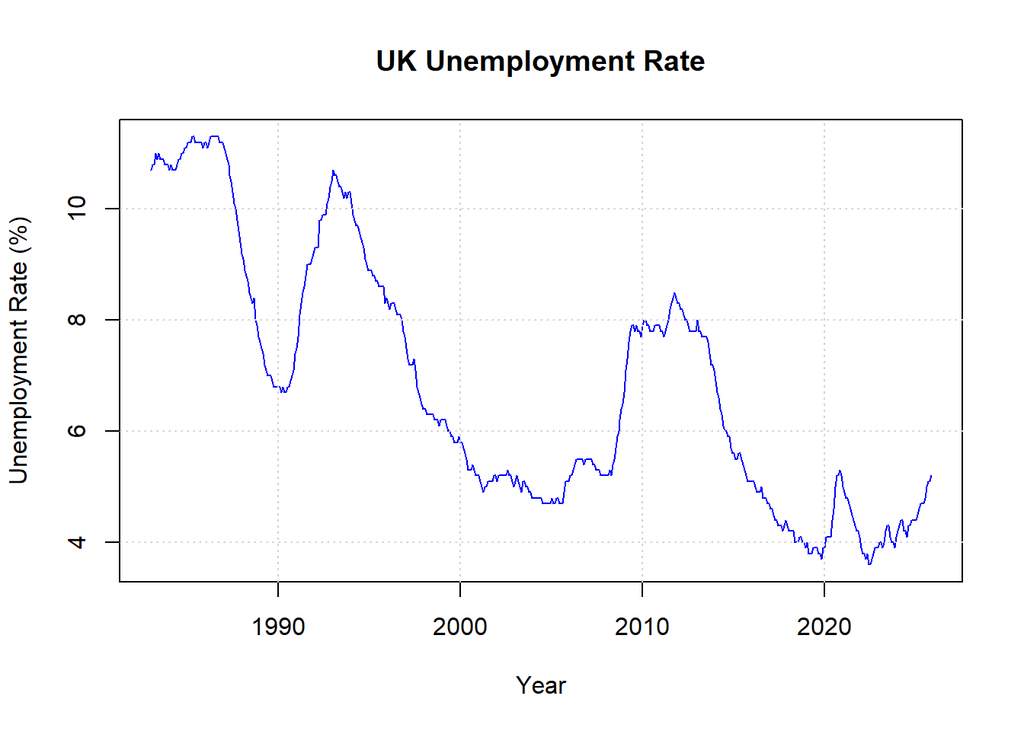

```r
plot(unemployment_TS,
     main = "UK Unemployment Rate",
     xlab = "Year",
     ylab = "Unemployment Rate (%)",
     col = "blue",
     type = "l")
grid()
```

The graph shows several important changes in the UK unemployment rate over time. Unemployment starts high, peaking at around 11% during the **1980s recession**. There is another peak in the early **1990s**, again linked to recession, before the rate falling steadily into the early 2000s. The **2008 financial crisis** caused another spike to around 8%, followed by a gradual decline to its lowest level of around 4% by the late 2010s. There is a small spike in 2020 due to the **COVID-19 pandemic**, after which unemployment returned to low levels. There is an overall downward trend in the long term, suggesting the UK labour market has strengthened over time.

### 1.4 Summary statistics

```r
summary(unemployment_TS)
```

```
##    Min. 1st Qu.  Median    Mean 3rd Qu.    Max.
##   3.600   4.900   6.200   6.796   8.300  11.300
```

The unemployment rate ranges widely from **3.6%** to **11.3%**. This shows that unemployment changed considerably over time, likely reflecting the impact of major economic events.

# 2. Trend Analysis

### 2.1 Linear Regression

A simple linear regression is fitted to explore the long term trend. This tells us whether unemployment has risen or fallen on average over time.

```r
linearModel = lm(unemployment_TS ~ time(unemployment_TS))
summary(linearModel)
```

```
##
## Call:
## lm(formula = unemployment_TS ~ time(unemployment_TS))
##
## Residuals:
##      Min       1Q   Median       3Q      Max
## -2.35754 -1.14789 -0.03257  1.18353  2.77244
##
## Coefficients:
##                         Estimate Std. Error t value Pr(>|t|)
## (Intercept)           298.864592   9.959674   30.01   <2e-16 ***
## time(unemployment_TS)  -0.145712   0.004969  -29.33   <2e-16 ***
## ---
## Signif. codes:  0 '***' 0.001 '**' 0.01 '*' 0.05 '.' 0.1 ' ' 1
##
## Residual standard error: 1.397 on 513 degrees of freedom
## Multiple R-squared:  0.6264, Adjusted R-squared:  0.6256
## F-statistic:   860 on 1 and 513 DF,  p-value: < 2.2e-16
```

The estimated coefficient for time is negative, suggesting that the unemployment rate has fallen on average over time. The p-value is very small, so this downward trend is statistically significant.

### 2.2 Linear Regression Plot

The trend line is plotted over the data using `abline()`.

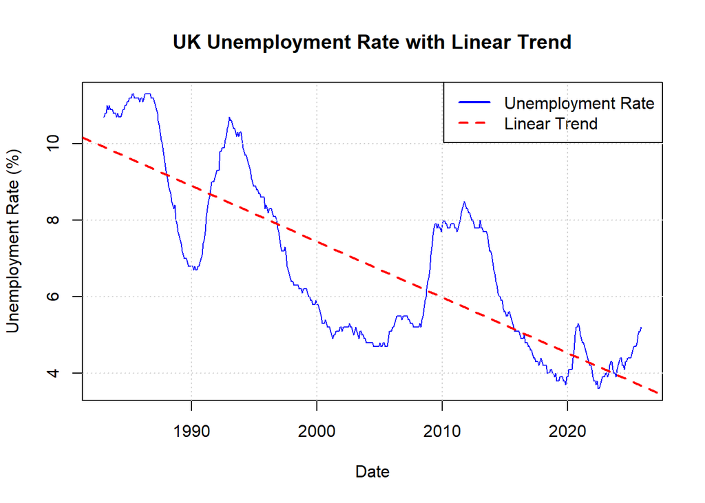

```r
plot(unemployment_TS,
    type = "l",
    main = "UK Unemployment Rate with Linear Trend",
    xlab = "Date",
    ylab = "Unemployment Rate (%)",
    col  = "blue"
)
abline(linearModel, col = "red", lwd = 2, lty = 2)
legend("topright",
       legend = c("Unemployment Rate", "Linear Trend"),
       col    = c("blue", "red"),
       lty    = c(1, 2),
       lwd    = 2)
grid()
```

The negative slope in the linear model shows that the UK unemployment rate has declined on average over time. However, a straight line is not the best fit for short-term analysis, as the unemployment rate rises and falls sharply around major economic events. This suggests that while the long-run trend is downward, unemployment is still heavily influenced by short-term economic shocks.

# 3. Forecasting with Meta’s Prophet

### 3.1 Prophet Model

[Meta’s Prophet](https://facebook.github.io/prophet/) is a forecasting tool designed for time series data with trend and seasonal patterns. It models the series using components such as trend and seasonality.

The main library needed in this section is `prophet` to fit the forecasting model. `ggplot2` is used to label the forecast plots.

```r
library(prophet)
library(ggplot2)
```

Prophet requires a dataframe with a column called `ds` for the dates and a column called `y` for the values.

```r
unemployment_prophet_data = data.frame(
    ds = as.Date(unemployment_data$Date),
    y = unemployment_data$UnemploymentRate
)
```

The data is checked before fitting the model.

```r
head(unemployment_prophet_data)
```

```
##           ds    y
## 1 1983-01-01 10.7
## 2 1983-02-01 10.8
## 3 1983-03-01 10.8
## 4 1983-04-01 11.0
## 5 1983-05-01 10.9
## 6 1983-06-01 11.0
```

### 3.2 Fitting the Prophet Model

The Prophet model is fitted using the `prophet()` function.

```r
unemployment_prophet_model = prophet(unemployment_prophet_data)
```

### 3.3 Creating Future Dates and Forecasting

We ask Prophet to forecast 12 months into the future.

```r
future_unemployment_dates = make_future_dataframe(
    unemployment_prophet_model,
    periods = 12,
    freq = "month"
)

unemployment_forecast = predict(
    unemployment_prophet_model,
    future_unemployment_dates
)
```

### 3.4 Forecast Plot

The forecast is plotted to compare the observed data with Prophet’s values.

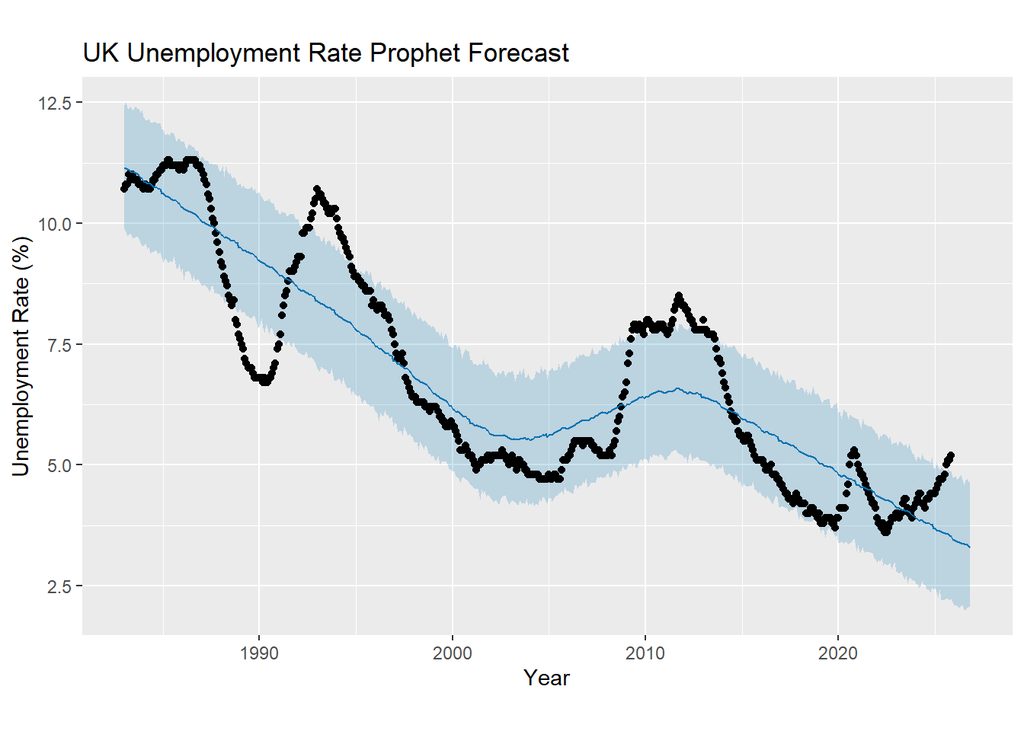

```r
plot(unemployment_prophet_model, unemployment_forecast,
     xlabel = "Year",
     ylabel = "Unemployment Rate (%)") +
    labs(title = "UK Unemployment Rate Prophet Forecast")
```

The black dots represent the observed data, the blue line shows Prophet’s fitted and forecast values, and the shaded region represents the uncertainty interval. The forecast suggests that unemployment may remain relatively low and could continue to decrease. Using a smaller and more recent date range might produce forecasts that are more relevant to current events.

### 3.5 Forecast Components

Prophet can also plot the individual components of the model, making it easier to see the trend and seasonal effects separately.

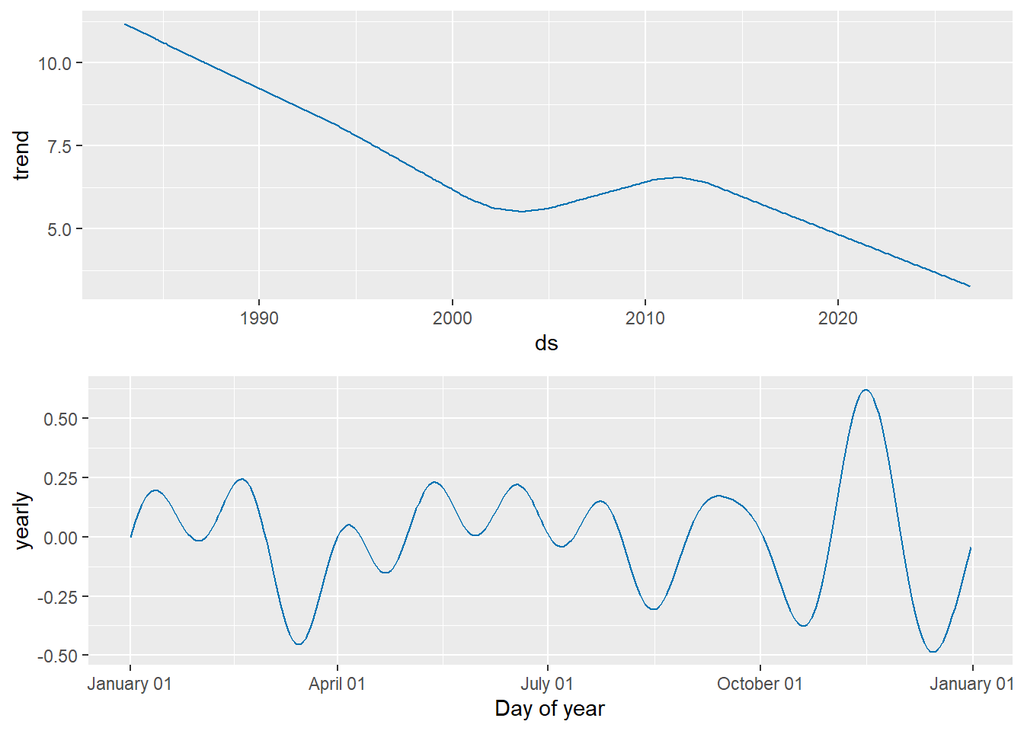

```r
prophet_plot_components(unemployment_prophet_model, unemployment_forecast)
```

The trend component suggests a general decline over the long run, with a temporary increase after the 2008 financial crisis before it continued to fall. The yearly seasonality component suggests small changes at different times of the year, although this effect is less noticeable than the overall trend.

# 4. Discussion

This analysis showed that UK unemployment has varied over time, with noticeable increases during major recessions. Overall, the long-term trend is downward, and the seasonal pattern is relatively weak.

The Prophet forecast suggests that unemployment may remain fairly low in the next few months, although uncertainty increases overtime. Since the model cannot account for unexpected economic shocks, the forecast should be treated as a baseline rather than an exact prediction.

# References

- RStudio reference: https://rmarkdown.rstudio.com/lesson-1.html
- FRED Database, Federal Reserve Bank of St. Louis: https://fred.stlouisfed.org/series/LRHUTTTTGBM156S
- Meta’s Prophet documentation: https://facebook.github.io/prophet/docs/quick_start.html